# MLB Postseason Analysis

賴昱堯

2018年11月14日

## 前言

美國職棒季後賽前不久才結束，由萬眾所矚的波士頓紅襪隊奪下世界冠軍，然而歷年來的世界冠軍並不都是一開始就被看好，因此我很好奇是否能夠從季賽中選手、球隊的表現看出一些端倪，故我抓了2018年全部球員的數據做分析。

[Source](https://www.baseball-reference.com/leagues/MLB/2018.shtml)

## 載入資料庫

```r
library(tidyverse)
library(readr)
library(ggplot2)
```

## 載入data

```r
setwd("~/GitHub/Rlanguage/week_7/hw/baseball")
batting <- read_csv("batting.csv")
standings <- read_csv("standings.csv")
pitching <- read_csv("pitching.csv")
team_standard_batting <- read_csv("team_standard_batting.csv")
team_fielding <- read_csv("team_fielding.csv")
team_standard_pitching <- read_csv("team_standard_pitching.csv")
ana_post_fielding <- read_csv("ana_post_fielding.csv")
ana_post_batting <- read_csv("ana_post_batting.csv")
ana_post_pitching <- read_csv("ana_post_pitching.csv")
```

## team vs value

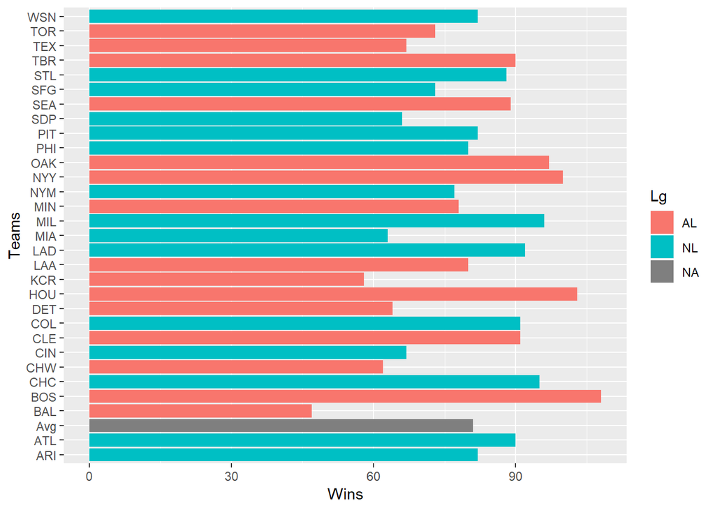

```r
ggplot(data = standings, mapping = aes(x = Tm, y = W, fill = Lg ))+
  geom_bar(stat = "identity")+
  coord_flip()+
  ylab("Wins")+
  xlab("Teams")
```

## batter(by team) vs stats

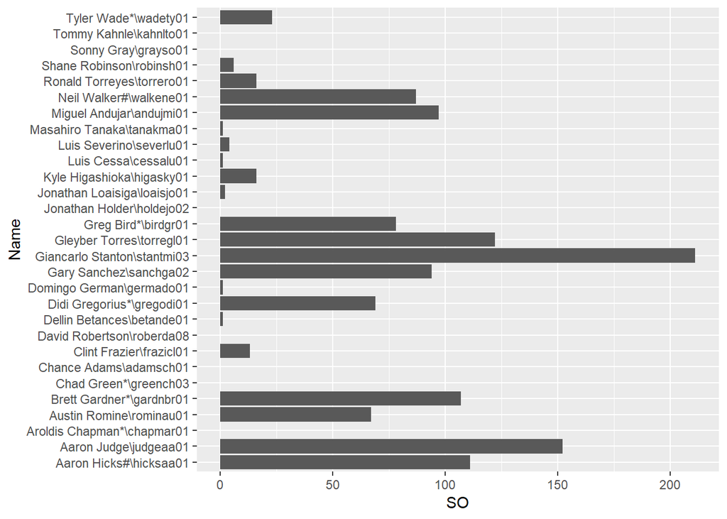

```r
selected_team_batter <- filter(batting, Tm=="NYY")
ggplot(data = selected_team_batter, mapping = aes_string(x ="Name", y = "SO"))+
       geom_bar(stat = "identity")+
       coord_flip()+
       ylab("SO")+
       xlab("Name")
```

## pitcher(by team) vs stats

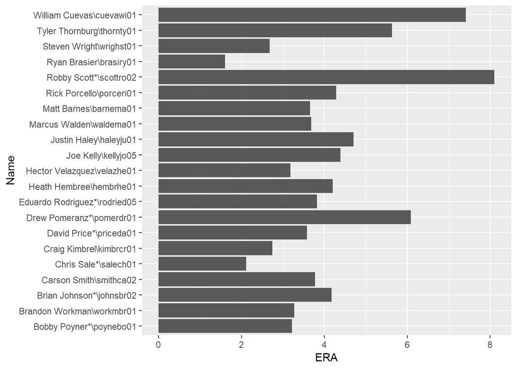

```r
selected_team_pitcher <- filter(pitching, Tm=="BOS")
ggplot(data = selected_team_pitcher, mapping = aes_string(x ="Name", y = "ERA"))+
       geom_bar(stat = "identity")+
       coord_flip()+
       ylab("ERA")+
       xlab("Name")
```

## comparison

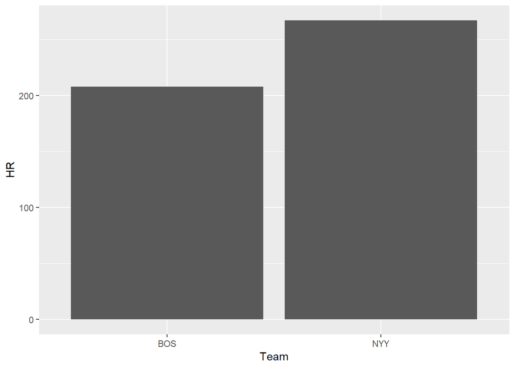

```r
selected_team_standard_batting <- filter(team_standard_batting, Tm=="BOS"|Tm=="NYY")
ggplot(data = selected_team_standard_batting, mapping = aes_string(x ="Tm", y = "HR"))+
       geom_bar(stat = "identity")+
       ylab("HR")+
       xlab("Team")
```

## analysis

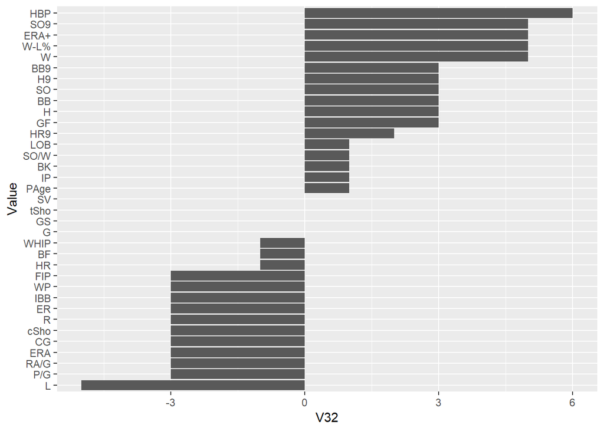

```r
ana_post_pitching$X1 <- factor(ana_post_pitching$X1, levels = ana_post_pitching$X1[order(ana_post_pitching$V32)])
ggplot(data = ana_post_pitching, mapping = aes(x=X1, y=V32))+
            geom_bar(stat = "identity")+
            coord_flip()+
            xlab("Value")
```

## conclusion

World Series 4-1 Boston Red Sox over Los Angeles Dodgers

ALCS 4-1 Boston Red Sox over Houston Astros

NLCS 4-3 Los Angeles Dodgers over Milwaukee Brewers

AL Division Series 3-1 Boston Red Sox over New York Yankees

AL Division Series 3-0 Houston Astros over Cleveland Indians

NL Division Series 3-0 Milwaukee Brewers over Colorado Rockies

NL Division Series 3-1 Los Angeles Dodgers over Atlanta Braves

Wild Card Game 1-0 New York Yankees over Oakland Athletics

Wild Card Game 1-0 Colorado Rockies over Chicago Cubs

- fielding
- NEGATIVE
- Rdrs
- DP Double play
- A assist
- Fld
- batting
- POSITIVE
- TB single+2double+3triple+4hr
- OPS+ on base slugging percentage
- OPS
- SLG bases record per bat
- OBP on base percentage
- RBI runs bat in
- R runs
- R/G
- NEGITIVE
- HBP hit bt pitch
- BAT number of players used per game
- pitching
- POSITIVE
- HBP hit by pitch
- SO9 strikeout per inn
- ERA+
- W-L%
- W
- NEGITIVE
- L lose